# Prediction Assignment

Jenny Biechele-Speziale

5/26/2020

# Load & Clean Data:

The data was loaded from the following links:

train data: https://d396qusza40orc.cloudfront.net/predmachlearn/pml-training.csv

test data: https://d396qusza40orc.cloudfront.net/predmachlearn/pml-testing.csv

Columns that were empty or had time data or window data were disregarded from the models, since this analysis does not require any time step data.

```r
#load data
library(readr)
pml_training <- read_csv("~/Downloads/pml-training.csv")
pml_testing <- read_csv("~/Downloads/pml-testing.csv")
#get rid of NA columns, get rid of time stamp data and window data
features<-names(pml_testing[,colSums(is.na(pml_testing))==0])[8:59]
DTtraining<-pml_training[,c(features,"classe")]
DTtesting<-pml_testing[,c(features,"problem_id")]
```

# Split Data

The train dataset (DTtraining) from above was split into a 60% training data set and a 40% testing set. The DTtesting dataset was not used for the data splitting, because that will be used for later predictions.

```r
library(caret)
set.seed(54)
inTrain<-createDataPartition(DTtraining$classe,p=0.6,list=FALSE)
training<-DTtraining[inTrain,]
testing<-DTtraining[-inTrain,]
```

# Analysis

For this assignment, various tree classifiers were used to solve this problem. I performed basic decision tree, boosted tree, and random forest models. Tree models were chosen because of their good performance with non-linear models, as well as their ease of implementation into R.

To reduce overfitting, a 10-fold cross-validation was used with the decision tree and boosted tree, but was not used in the random forest model, since cross-validation is not necessary for this model type.

## Basic Decision Tree Model and Prediction

```r
library(rpart)
library(rpart.plot)
library(rattle)
set.seed(54)
modFitDT<-rpart(classe~.,data=training,method="class",control = rpart.control(method="cv",number=10))
#in-sample predictions
predDTis<-predict(modFitDT,testing,type="class")
confusionMatrix(predDTis,as.factor(testing$classe))
```

```
## Confusion Matrix and Statistics
##
##           Reference
## Prediction    A    B    C    D    E
##          A 2002  297   14   94   86
##          B   51  853  165   69  102
##          C   54  214 1007  114  104
##          D   98  101  101  892  121
##          E   27   53   81  117 1029
##
## Overall Statistics
##
##                Accuracy : 0.7371
##                  95% CI : (0.7272, 0.7468)
##     No Information Rate : 0.2845
##     P-Value [Acc > NIR] : < 2.2e-16
##
##                   Kappa : 0.6662
##
##  Mcnemar's Test P-Value : < 2.2e-16
##
## Statistics by Class:
##
##                      Class: A Class: B Class: C Class: D Class: E
## Sensitivity            0.8970   0.5619   0.7361   0.6936   0.7136
## Specificity            0.9125   0.9388   0.9250   0.9358   0.9566
## Pos Pred Value         0.8030   0.6879   0.6745   0.6794   0.7873
## Neg Pred Value         0.9570   0.8993   0.9432   0.9397   0.9368
## Prevalence             0.2845   0.1935   0.1744   0.1639   0.1838
## Detection Rate         0.2552   0.1087   0.1283   0.1137   0.1311
## Detection Prevalence   0.3177   0.1580   0.1903   0.1673   0.1666
## Balanced Accuracy      0.9047   0.7504   0.8305   0.8147   0.8351
```

```r
#out-of-sample predictions
predDToos<-predict(modFitDT,DTtesting)
```

## Boosting Model and Prediction

```r
library(gbm)
set.seed(54)
modFitB<-train(classe ~ ., method = "gbm", data = training,verbose=FALSE,trControl=trainControl(method="cv",number=10))
modFitB
```

```
## Stochastic Gradient Boosting
##
## 11776 samples
##    52 predictor
##     5 classes: 'A', 'B', 'C', 'D', 'E'
##
## No pre-processing
## Resampling: Cross-Validated (10 fold)
## Summary of sample sizes: 10598, 10597, 10599, 10599, 10598, 10599, ...
## Resampling results across tuning parameters:
##
##   interaction.depth  n.trees  Accuracy   Kappa
##   1                   50      0.7523751  0.6857281
##   1                  100      0.8209906  0.7733983
##   1                  150      0.8519854  0.8126427
##   2                   50      0.8536000  0.8145374
##   2                  100      0.9054851  0.8804074
##   2                  150      0.9310457  0.9127535
##   3                   50      0.8956338  0.8678479
##   3                  100      0.9402156  0.9243423
##   3                  150      0.9593229  0.9485284
##
## Tuning parameter 'shrinkage' was held constant at a value of 0.1
##
## Tuning parameter 'n.minobsinnode' was held constant at a value of 10
## Accuracy was used to select the optimal model using the largest value.
## The final values used for the model were n.trees = 150, interaction.depth =
##  3, shrinkage = 0.1 and n.minobsinnode = 10.
```

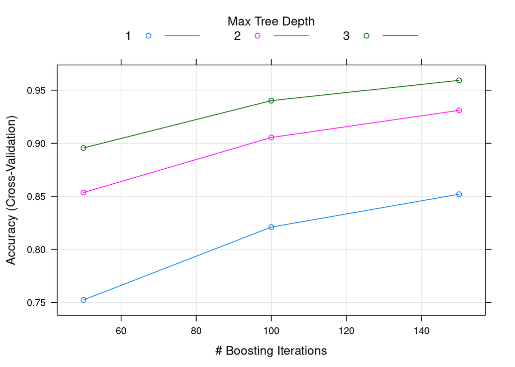

```r
plot(modFitB)
```

```r
#in-sample prediction
predBis<-predict(modFitB,testing)
confusionMatrix(predBis,as.factor(testing$classe))
```

```
## Confusion Matrix and Statistics
##
##           Reference
## Prediction    A    B    C    D    E
##          A 2198   46    0    3    2
##          B   17 1436   49    7   17
##          C    9   31 1297   45   19
##          D    5    2   17 1216   22
##          E    3    3    5   15 1382
##
## Overall Statistics
##
##                Accuracy : 0.9596
##                  95% CI : (0.955, 0.9638)
##     No Information Rate : 0.2845
##     P-Value [Acc > NIR] : < 2.2e-16
##
##                   Kappa : 0.9489
##
##  Mcnemar's Test P-Value : 1.642e-09
##
## Statistics by Class:
##
##                      Class: A Class: B Class: C Class: D Class: E
## Sensitivity            0.9848   0.9460   0.9481   0.9456   0.9584
## Specificity            0.9909   0.9858   0.9839   0.9930   0.9959
## Pos Pred Value         0.9773   0.9410   0.9258   0.9635   0.9815
## Neg Pred Value         0.9939   0.9870   0.9890   0.9894   0.9907
## Prevalence             0.2845   0.1935   0.1744   0.1639   0.1838
## Detection Rate         0.2801   0.1830   0.1653   0.1550   0.1761
## Detection Prevalence   0.2866   0.1945   0.1786   0.1608   0.1795
## Balanced Accuracy      0.9878   0.9659   0.9660   0.9693   0.9772
```

```r
#out of sample prediction
predBoos<-predict(modFitB,DTtesting)
```

## Random Forest Model and Prediction

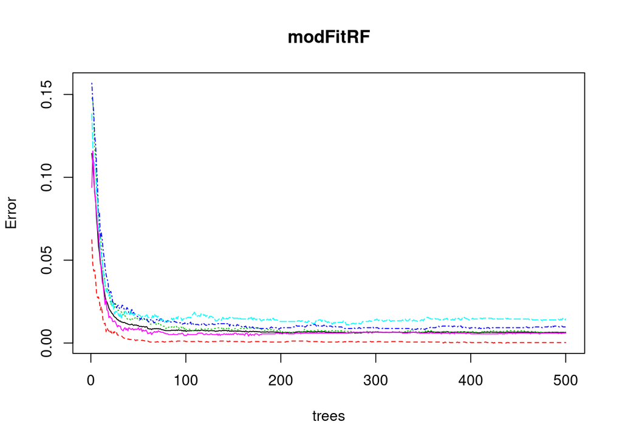

```r
library(randomForest)
set.seed(54)
modFitRF<-randomForest(as.factor(classe) ~ ., data = training, method = "rf", importance = TRUE)
plot(modFitRF)
```

```r
#in-sample predictions
predRF<-predict(modFitRF,testing,type="class")
confusionMatrix(predRF,as.factor(testing$classe))
```

```
## Confusion Matrix and Statistics
##
##           Reference
## Prediction    A    B    C    D    E
##          A 2232    9    0    0    0
##          B    0 1507   12    0    0
##          C    0    2 1356   16    1
##          D    0    0    0 1269    2
##          E    0    0    0    1 1439
##
## Overall Statistics
##
##                Accuracy : 0.9945
##                  95% CI : (0.9926, 0.996)
##     No Information Rate : 0.2845
##     P-Value [Acc > NIR] : < 2.2e-16
##
##                   Kappa : 0.9931
##
##  Mcnemar's Test P-Value : NA
##
## Statistics by Class:
##
##                      Class: A Class: B Class: C Class: D Class: E
## Sensitivity            1.0000   0.9928   0.9912   0.9868   0.9979
## Specificity            0.9984   0.9981   0.9971   0.9997   0.9998
## Pos Pred Value         0.9960   0.9921   0.9862   0.9984   0.9993
## Neg Pred Value         1.0000   0.9983   0.9981   0.9974   0.9995
## Prevalence             0.2845   0.1935   0.1744   0.1639   0.1838
## Detection Rate         0.2845   0.1921   0.1728   0.1617   0.1834
## Detection Prevalence   0.2856   0.1936   0.1752   0.1620   0.1835
## Balanced Accuracy      0.9992   0.9954   0.9941   0.9932   0.9989
```

```r
#out-of-sample predictions
predRFoos<-predict(modFitRF,DTtesting)
```

# Prediction (out-of-sample)

The out-of-sample predictions are as follows for each of the models:

```r
predDToos
```

```
##             A           B          C          D          E
## 1  0.02875399 0.150159744 0.56869010 0.18530351 0.06709265
## 2  0.68464730 0.203319502 0.01541197 0.07291049 0.02371073
## 3  0.04938272 0.283950617 0.65432099 0.00000000 0.01234568
## 4  0.13642961 0.050798258 0.12336720 0.64876633 0.04063861
## 5  0.71802326 0.139534884 0.00000000 0.02906977 0.11337209
## 6  0.03330250 0.176688252 0.56891767 0.10083256 0.12025902
## 7  0.07504078 0.061990212 0.05872757 0.69331158 0.11092985
## 8  0.08637874 0.089700997 0.16943522 0.15614618 0.49833887
## 9  0.99145299 0.008547009 0.00000000 0.00000000 0.00000000
## 10 0.68464730 0.203319502 0.01541197 0.07291049 0.02371073
## 11 0.02662722 0.511834320 0.17455621 0.10059172 0.18639053
## 12 0.02662722 0.511834320 0.17455621 0.10059172 0.18639053
## 13 0.01535509 0.145873321 0.06525912 0.21113244 0.56238004
## 14 0.99145299 0.008547009 0.00000000 0.00000000 0.00000000
## 15 0.01535509 0.145873321 0.06525912 0.21113244 0.56238004
## 16 0.71802326 0.139534884 0.00000000 0.02906977 0.11337209
## 17 0.97849462 0.000000000 0.01075269 0.00000000 0.01075269
## 18 0.68464730 0.203319502 0.01541197 0.07291049 0.02371073
## 19 0.68464730 0.203319502 0.01541197 0.07291049 0.02371073
## 20 0.02662722 0.511834320 0.17455621 0.10059172 0.18639053
```

```r
predBoos
```

```
##  [1] B A B A A E D B A A B C B A E E A B B B
## Levels: A B C D E
```

```r
predRFoos
```

```
##  1  2  3  4  5  6  7  8  9 10 11 12 13 14 15 16 17 18 19 20
##  B  A  B  A  A  E  D  B  A  A  B  C  B  A  E  E  A  B  B  B
## Levels: A B C D E
```

```r
predBoos==predRFoos
```

```
##  [1] TRUE TRUE TRUE TRUE TRUE TRUE TRUE TRUE TRUE TRUE TRUE TRUE TRUE TRUE TRUE
## [16] TRUE TRUE TRUE TRUE TRUE
```

Both the boosted and random forest models get the exact same (and correct) prediction on the DTtesting set.